# Modeling and Simulation in Python

Chapter 4

Copyright 2017 Allen Downey

License: [Creative Commons Attribution 4.0 International](https://creativecommons.org/licenses/by/4.0)

```python
# Configure Jupyter so figures appear in the notebook
%matplotlib inline

# Configure Jupyter to display the assigned value after an assignment
%config InteractiveShell.ast_node_interactivity='last_expr_or_assign'

# import functions from the modsim library
from modsim import *

import statistics
```

## Returning values

Here's a simple function that returns a value:

```python
def add_five(x):
    return x + 5
```

And here's how we call it.

```python
y = add_five(3)
```

```
8
```

If you run a function on the last line of a cell, Jupyter displays the result:

```python
add_five(5)
```

```
10
```

But that can be a bad habit, because usually if you call a function and don't assign the result in a variable, the result gets discarded.

In the following example, Jupyter shows the second result, but the first result just disappears.

```python
add_five(3)
add_five(5)
```

```
10
```

When you call a function that returns a variable, it is generally a good idea to assign the result to a variable.

```python
y1 = add_five(3)
y2 = add_five(5)

print(y1, y2)
```

```
8 10
```

**Exercise:** Write a function called `make_state` that creates a `State` object with the state variables `olin=10` and `wellesley=2`, and then returns the new `State` object.

Write a line of code that calls `make_state` and assigns the result to a variable named `init`.

```python
def make_state():
    state = State(olin=10, wellesley=2)
    return state
```

```python
init = make_state()
```

|  | values |
| --- | --- |
| olin | 10 |
| wellesley | 2 |

## Running simulations

Here's the code from the previous notebook.

```python
def step(state, p1, p2):
    """Simulate one minute of time.

    state: bikeshare State object
    p1: probability of an Olin->Wellesley customer arrival
    p2: probability of a Wellesley->Olin customer arrival
    """
    if flip(p1):
        bike_to_wellesley(state)

    if flip(p2):
        bike_to_olin(state)

def bike_to_wellesley(state):
    """Move one bike from Olin to Wellesley.

    state: bikeshare State object
    """
    if state.olin == 0:
        state.olin_empty += 1
        return
    state.olin -= 1
    state.wellesley += 1

def bike_to_olin(state):
    """Move one bike from Wellesley to Olin.

    state: bikeshare State object
    """
    if state.wellesley == 0:
        state.wellesley_empty += 1
        return
    state.wellesley -= 1
    state.olin += 1

def decorate_bikeshare():
    """Add a title and label the axes."""
    decorate(title='Olin-Wellesley Bikeshare',
             xlabel='Time step (min)',
             ylabel='Number of bikes')
```

Here's a modified version of `run_simulation` that creates a `State` object, runs the simulation, and returns the `State` object.

```python
def run_simulation(p1, p2, num_steps):
    """Simulate the given number of time steps.

    p1: probability of an Olin->Wellesley customer arrival
    p2: probability of a Wellesley->Olin customer arrival
    num_steps: number of time steps
    """
    state = State(olin=10, wellesley=2,
                  olin_empty=0, wellesley_empty=0)

    for i in range(num_steps):
        step(state, p1, p2)

    return state
```

Now `run_simulation` doesn't plot anything:

```python
state = run_simulation(0.4, 0.2, 60)
```

|  | values |
| --- | --- |
| olin | 2 |
| wellesley | 10 |
| olin_empty | 4 |
| wellesley_empty | 0 |

But after the simulation, we can read the metrics from the `State` object.

```python
state.olin_empty
```

```
4
```

Now we can run simulations with different values for the parameters. When `p1` is small, we probably don't run out of bikes at Olin.

```python
state = run_simulation(0.2, 0.2, 60)
state.olin_empty
```

```
0
```

When `p1` is large, we probably do.

```python
state = run_simulation(0.6, 0.2, 60)
state.olin_empty
```

```
22
```

## More for loops

`linspace` creates a NumPy array of equally spaced numbers.

```python
p1_array = linspace(0, 1, 5)
```

```
array([0.  , 0.25, 0.5 , 0.75, 1.  ])
```

We can use an array in a `for` loop, like this:

```python
for p1 in p1_array:
    print(p1)
```

```
0.0
0.25
0.5
0.75
1.0
```

This will come in handy in the next section.

`linspace` is defined in `modsim.py`. You can get the documentation using `help`.

```python
help(linspace)
```

```
Help on function linspace in module modsim.modsim:

linspace(start, stop, num=50, **options)
    Returns an array of evenly-spaced values in the interval [start, stop].

    start: first value
    stop: last value
    num: number of values

    Also accepts the same keyword arguments as np.linspace.  See
    https://docs.scipy.org/doc/numpy/reference/generated/numpy.linspace.html

    returns: array or Quantity
```

`linspace` is based on a NumPy function with the same name. [Click here](https://docs.scipy.org/doc/numpy/reference/generated/numpy.linspace.html) to read more about how to use it.

**Exercise:** Use `linspace` to make an array of 10 equally spaced numbers from 1 to 10 (including both).

```python
p2_array = linspace(1,10,11)
```

```
array([ 1. ,  1.9,  2.8,  3.7,  4.6,  5.5,  6.4,  7.3,  8.2,  9.1, 10. ])
```

**Exercise:** The `modsim` library provides a related function called `linrange`. You can view the documentation by running the following cell:

```python
help(linrange)
```

```
Help on function linrange in module modsim.modsim:

linrange(start=0, stop=None, step=1, endpoint=False, **options)
    Returns an array of evenly-spaced values in an interval.

    By default, the last value in the array is `stop-step`
    (at least approximately).
    If you provide the keyword argument `endpoint=True`,
    the last value in the array is `stop`.

    This function works best if the space between start and stop
    is divisible by step; otherwise the results might be surprising.

    start: first value
    stop: last value
    step: space between values

    returns: NumPy array
```

Use `linrange` to make an array of numbers from 1 to 11 with a step size of 2.

```python
linrange(1,11,2, endpoint=True)
```

```
array([ 1,  3,  5,  7,  9, 11], dtype=int32)
```

## Sweeping parameters

`p1_array` contains a range of values for `p1`.

```python
p2 = 0.2
num_steps = 60
p1_array = linspace(0, 1, 11)
```

```
array([0. , 0.1, 0.2, 0.3, 0.4, 0.5, 0.6, 0.7, 0.8, 0.9, 1. ])
```

The following loop runs a simulation for each value of `p1` in `p1_array`; after each simulation, it prints the number of unhappy customers at the Olin station:

```python
for p1 in p1_array:
    state = run_simulation(p1, p2, num_steps)
    print(p1, state.olin_empty)
```

```
0.0 0
0.1 0
0.2 0
0.30000000000000004 0
0.4 8
0.5 17
0.6000000000000001 11
0.7000000000000001 21
0.8 29
0.9 33
1.0 34
```

Now we can do the same thing, but storing the results in a `SweepSeries` instead of printing them.

```python
sweep = SweepSeries()

for p1 in p1_array:
    state = run_simulation(p1, p2, num_steps)
    sweep[p1] = state.olin_empty
```

And then we can plot the results.

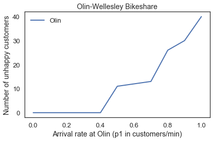

```python
plot(sweep, label='Olin')

decorate(title='Olin-Wellesley Bikeshare',
         xlabel='Arrival rate at Olin (p1 in customers/min)',
         ylabel='Number of unhappy customers')
```

## Exercises

**Exercise:** Wrap this code in a function named `sweep_p1` that takes an array called `p1_array` as a parameter. It should create a new `SweepSeries`, run a simulation for each value of `p1` in `p1_array`, store the results in the `SweepSeries`, and return the `SweepSeries`.

Use your function to plot the number of unhappy customers at Olin as a function of `p1`. Label the axes.

```python
def sweep_p1():

    sweep1 = SweepSeries()
    state1 = State(olin=10, wellesley=2,
                  olin_empty=0, wellesley_empty=0)

    p2 = 0.2
    num_steps = 60
    p1_array = linspace(0, 1, 11)

    for p1 in p1_array:
        state1 = run_simulation(p1, p2, num_steps)
        sweep1[p1] = state1.olin_empty

    plot(sweep1, label='Olin')

    decorate(title='Olin-Wellesley Bikeshare',
         xlabel='Arrival rate at Olin (p1 in customers/min)',
         ylabel='Number of unhappy customers')
```

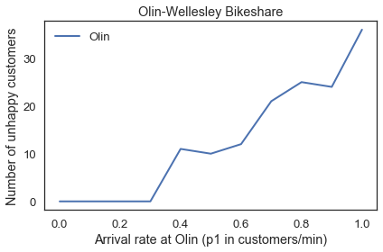

```python
sweep_p1()
```

**Exercise:** Write a function called `sweep_p2` that runs simulations with `p1=0.5` and a range of values for `p2`. It should store the results in a `SweepSeries` and return the `SweepSeries`.

```python
def sweep_p2():
    sweep2 = SweepSeries()
    state2 = State(olin=10, wellesley=2,
                  olin_empty=0, wellesley_empty=0)

    p1 = 0.5
    num_steps = 60
    p2_array = linspace(0, 1, 11)

    for p2 in p2_array:
        state2 = run_simulation(p1, p2, num_steps)
        sweep2[p2] = state2.wellesley_empty

    plot(sweep2, label='Wellesley')

    decorate(title='Olin-Wellesley Bikeshare',
         xlabel='Arrival rate at Olin (p1 in customers/min)',
         ylabel='Number of unhappy customers')
```

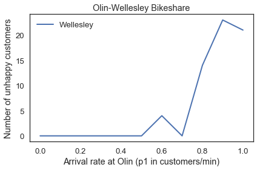

```python
sweep_p2()
```

## Optional Exercises

The following two exercises are a little more challenging. If you are comfortable with what you have learned so far, you should give them a try. If you feel like you have your hands full, you might want to skip them for now.

**Exercise:** Because our simulations are random, the results vary from one run to another, and the results of a parameter sweep tend to be noisy. We can get a clearer picture of the relationship between a parameter and a metric by running multiple simulations with the same parameter and taking the average of the results.

Write a function called `run_multiple_simulations` that takes as parameters `p1`, `p2`, `num_steps`, and `num_runs`.

`num_runs` specifies how many times it should call `run_simulation`.

After each run, it should store the total number of unhappy customers (at Olin or Wellesley) in a `TimeSeries`. At the end, it should return the `TimeSeries`.

Test your function with parameters

```
p1 = 0.3
p2 = 0.3
num_steps = 60
num_runs = 10
```

Display the resulting `TimeSeries` and use the `mean` function provided by the `TimeSeries` object to compute the average number of unhappy customers (see Section 2.7).

```python
def run_multiple_simulations(p1, p2, num_steps, num_runs):
    multi_results_olin = TimeSeries()

    state = State(olin=10, wellesley=2,
                      olin_empty=0, wellesley_empty=0)

    myarr=np.random.uniform(1,4)
    myarr2=np.random.uniform(1,3)

    def bike_to_wellesley(state2):
        if state.olin == 0:
            return
        state.olin -= myarr
        state.wellesley += myarr

    def bike_to_olin(state2):
        if state.wellesley ==0:
            return
        state.wellesley -= myarr
        state.olin += myarr

    def step(state2, p1, p2):
        if flip(p1):
            bike_to_wellesley(state)
        if flip(p2):
            bike_to_olin(state)

    for i in range (num_steps):
        step(state, p1, p2)
        multi_results_olin[i]=state.olin

    return multi_results_olin
```

```python
run_multiple_simulations(0.3,0.3,60,10)
```

[output not shown]

```python
state.olin
```

```
0
```

**Exercise:** Continuting the previous exercise, use `run_multiple_simulations` to run simulations with a range of values for `p1` and

```
p2 = 0.3
num_steps = 60
num_runs = 20
```

Store the results in a `SweepSeries`, then plot the average number of unhappy customers as a function of `p1`. Label the axes.

What value of `p1` minimizes the average number of unhappy customers?

```python
def run_multiple_simulations(p2, num_steps, num_runs):
    sweep = SweepSeries()
    multi_sweep=SweepSeries()

    p1_array = linspace(0, 1, 11)

    state = State(olin=10, wellesley=2,
                      olin_empty=0, wellesley_empty=0)

    myarr=np.random.uniform(1,4)
    myarr2=np.random.uniform(1,3)

    def run_simulation(p1, p2, num_steps):

        for i in range(num_steps):
            step(state, p1, p2)
            return state

    def sweep_exer(p2, num_steps):

        for p1 in p1_array:
            state1 = run_simulation(p1, p2, num_steps)
            sweep[p1] = state.olin

    for i in range (num_runs):
        sweep_exer(p2, num_steps)
        multi_sweep[i]=state.olin


    plot(multi_sweep, label='Wellesley')

    decorate(title='Olin-Wellesley Bikeshare',
             xlabel='Arrival rate at Olin (p1 in customers/min)',
             ylabel='Number of unhappy customers')
```

[figure not shown]

```python
run_multiple_simulations(0.3, 60, 20)
# run_multiple_simulations(0.3, 60, 20)
```